# Project: Investigate The TMDb Movies Dataset

- Introduction
- Data Wrangling
- Exploratory Data Analysis
- Conclusions

## Introduction

> The data set being investigated contains information about 10,000 movies collected from The Movie Database (TMDb). It includes cast, user ratings, budget and revenue. The goal of this project is to go through the data analysis process which are assesing, cleaning and analysing the resulting data which is going to give us insight of the movie industry. Lets look at the dataset to get a general idea of what we are working with.

```python
# Import Packages
import pandas as pd
import numpy as np
import matplotlib.pyplot as plt
import seaborn as sns
%matplotlib inline
```

```python
#Load data.
movie_df = pd.read_csv('tmdb-movies.csv')

#Check few data in the dataset
movie_df.head(2)
```

|  | id | imdb_id | popularity | budget | revenue | original_title | cast | homepage | director | tagline | ... | overview | runtime | genres | production_companies | release_date | vote_count | vote_average | release_year | budget_adj | revenue_adj |
| --- | --- | --- | --- | --- | --- | --- | --- | --- | --- | --- | --- | --- | --- | --- | --- | --- | --- | --- | --- | --- | --- |
| 0 | 135397 | tt0369610 | 32.985763 | 150000000 | 1513528810 | Jurassic World | Chris Pratt\|Bryce Dallas Howard\|Irrfan Khan\|Vi... | http://www.jurassicworld.com/ | Colin Trevorrow | The park is open. | ... | Twenty-two years after the events of Jurassic ... | 124 | Action\|Adventure\|Science Fiction\|Thriller | Universal Studios\|Amblin Entertainment\|Legenda... | 6/9/15 | 5562 | 6.5 | 2015 | 1.379999e+08 | 1.392446e+09 |
| 1 | 76341 | tt1392190 | 28.419936 | 150000000 | 378436354 | Mad Max: Fury Road | Tom Hardy\|Charlize Theron\|Hugh Keays-Byrne\|Nic... | http://www.madmaxmovie.com/ | George Miller | What a Lovely Day. | ... | An apocalyptic story set in the furthest reach... | 120 | Action\|Adventure\|Science Fiction\|Thriller | Village Roadshow Pictures\|Kennedy Miller Produ... | 5/13/15 | 6185 | 7.1 | 2015 | 1.379999e+08 | 3.481613e+08 |

2 rows × 21 columns

```python
# Check the last rows of the dataset
movie_df.tail(2)
```

|  | id | imdb_id | popularity | budget | revenue | original_title | cast | homepage | director | tagline | ... | overview | runtime | genres | production_companies | release_date | vote_count | vote_average | release_year | budget_adj | revenue_adj |
| --- | --- | --- | --- | --- | --- | --- | --- | --- | --- | --- | --- | --- | --- | --- | --- | --- | --- | --- | --- | --- | --- |
| 10864 | 21449 | tt0061177 | 0.064317 | 0 | 0 | What's Up, Tiger Lily? | Tatsuya Mihashi\|Akiko Wakabayashi\|Mie Hama\|Joh... | NaN | Woody Allen | WOODY ALLEN STRIKES BACK! | ... | In comic Woody Allen's film debut, he took the... | 80 | Action\|Comedy | Benedict Pictures Corp. | 11/2/66 | 22 | 5.4 | 1966 | 0.000000 | 0.0 |
| 10865 | 22293 | tt0060666 | 0.035919 | 19000 | 0 | Manos: The Hands of Fate | Harold P. Warren\|Tom Neyman\|John Reynolds\|Dian... | NaN | Harold P. Warren | It's Shocking! It's Beyond Your Imagination! | ... | A family gets lost on the road and stumbles up... | 74 | Horror | Norm-Iris | 11/15/66 | 15 | 1.5 | 1966 | 127642.279154 | 0.0 |

2 rows × 21 columns

### Brainstorming Questions

> After visually analysing the dataset,the following question are going to help in the analysis. These are question we are interested in about the dataset
> 1. Which directors have directed the most movies? Top 20.
> 2. Which actors/actress have acted the most movies? Top 20.
> 3. Which genres have the highest release? Top 20.
> 4. Which production companies have produced the most movies? Top 20.
> 5. Which year has the highest movie release?
> 6. Which movies have longest and shortest runtime?
> 7. Which movies have the highest and lowest ratings?
> 8. Which movies have the highest and lowest budget? Top 20.
> 9. Which movies have the highest and lowest revenue? Top 20.
> 10. Which movies have the highest profit and loss? Top 20.
> 11. Which properties are associated with high profits and ratings.

## Data Wrangling

> Data wrangling helps in ensuring one has quality data for analysis. These are collecting, assesing and cleaning data for analysis and visualization. Since we already have our data, we can go ahead and assess and clean our data. We are first going to assess the dataset and build intuition before cleaning it.

### General Properties

```python
# Check the dataset dimensions
movie_df.shape
```

```
(10866, 21)
```

```python
# Check for the general characteristics of the dataframe
movie_df.info()
```

```
<class 'pandas.core.frame.DataFrame'>
RangeIndex: 10866 entries, 0 to 10865
Data columns (total 21 columns):
 #   Column                Non-Null Count  Dtype
---  ------                --------------  -----
 0   id                    10866 non-null  int64
 1   imdb_id               10856 non-null  object
 2   popularity            10866 non-null  float64
 3   budget                10866 non-null  int64
 4   revenue               10866 non-null  int64
 5   original_title        10866 non-null  object
 6   cast                  10790 non-null  object
 7   homepage              2936 non-null   object
 8   director              10822 non-null  object
 9   tagline               8042 non-null   object
 10  keywords              9373 non-null   object
 11  overview              10862 non-null  object
 12  runtime               10866 non-null  int64
 13  genres                10843 non-null  object
 14  production_companies  9836 non-null   object
 15  release_date          10866 non-null  object
 16  vote_count            10866 non-null  int64
 17  vote_average          10866 non-null  float64
 18  release_year          10866 non-null  int64
 19  budget_adj            10866 non-null  float64
 20  revenue_adj           10866 non-null  float64
dtypes: float64(4), int64(6), object(11)
memory usage: 1.7+ MB
```

```python
# Check for the statistical summary of the dataset
movie_df.describe()
```

|  | id | popularity | budget | revenue | runtime | vote_count | vote_average | release_year | budget_adj | revenue_adj |
| --- | --- | --- | --- | --- | --- | --- | --- | --- | --- | --- |
| count | 10866.000000 | 10866.000000 | 1.086600e+04 | 1.086600e+04 | 10866.000000 | 10866.000000 | 10866.000000 | 10866.000000 | 1.086600e+04 | 1.086600e+04 |
| mean | 66064.177434 | 0.646441 | 1.462570e+07 | 3.982332e+07 | 102.070863 | 217.389748 | 5.974922 | 2001.322658 | 1.755104e+07 | 5.136436e+07 |
| std | 92130.136561 | 1.000185 | 3.091321e+07 | 1.170035e+08 | 31.381405 | 575.619058 | 0.935142 | 12.812941 | 3.430616e+07 | 1.446325e+08 |
| min | 5.000000 | 0.000065 | 0.000000e+00 | 0.000000e+00 | 0.000000 | 10.000000 | 1.500000 | 1960.000000 | 0.000000e+00 | 0.000000e+00 |
| 25% | 10596.250000 | 0.207583 | 0.000000e+00 | 0.000000e+00 | 90.000000 | 17.000000 | 5.400000 | 1995.000000 | 0.000000e+00 | 0.000000e+00 |
| 50% | 20669.000000 | 0.383856 | 0.000000e+00 | 0.000000e+00 | 99.000000 | 38.000000 | 6.000000 | 2006.000000 | 0.000000e+00 | 0.000000e+00 |
| 75% | 75610.000000 | 0.713817 | 1.500000e+07 | 2.400000e+07 | 111.000000 | 145.750000 | 6.600000 | 2011.000000 | 2.085325e+07 | 3.369710e+07 |
| max | 417859.000000 | 32.985763 | 4.250000e+08 | 2.781506e+09 | 900.000000 | 9767.000000 | 9.200000 | 2015.000000 | 4.250000e+08 | 2.827124e+09 |

### Data Cleaning

Data cleaning is a very important step as it helps to get the data set into a form that ne can work with or easy to analyse. After assesing the dataset, the following steps will be helpful in cleaning the data;

Dropping unncessary columns

Changing the datatypes of column which are wrong

Dropping duplicates

Droping null value

Fill any missing data that is important

#### Dropping Unnecessary columns.

```python
# drop columns
movie_df.drop(['imdb_id','homepage','tagline','overview','budget_adj','revenue_adj','keywords'], axis=1, inplace=True)

#Confirm that you have dropped intended columns
movie_df.info()
```

```
<class 'pandas.core.frame.DataFrame'>
RangeIndex: 10866 entries, 0 to 10865
Data columns (total 14 columns):
 #   Column                Non-Null Count  Dtype
---  ------                --------------  -----
 0   id                    10866 non-null  int64
 1   popularity            10866 non-null  float64
 2   budget                10866 non-null  int64
 3   revenue               10866 non-null  int64
 4   original_title        10866 non-null  object
 5   cast                  10790 non-null  object
 6   director              10822 non-null  object
 7   runtime               10866 non-null  int64
 8   genres                10843 non-null  object
 9   production_companies  9836 non-null   object
 10  release_date          10866 non-null  object
 11  vote_count            10866 non-null  int64
 12  vote_average          10866 non-null  float64
 13  release_year          10866 non-null  int64
dtypes: float64(2), int64(6), object(6)
memory usage: 1.2+ MB
```

#### Correcting datatypes

```python
# Change 'release_date' datatype
movie_df['release_date'] = movie_df['release_date'].astype('datetime64')
movie_df['release_date'].head(2)
```

```
0   2015-06-09
1   2015-05-13
Name: release_date, dtype: datetime64[ns]
```

#### Dropping Duplicates.

Sometimes data contains duplicates. If this issue is not addressed, we might get misleading data.

```python
#Check for any duplicates
movie_df.duplicated().sum()
```

```
1
```

```python
#Drop the duplicates found
movie_df.drop_duplicates(keep='first', inplace=True)
movie_df.duplicated().sum()
```

```
0
```

#### Dropping nulls

Data sometimes contains null values. It is always important to check out for them.

```python
#Check for nulls
movie_df.isna().sum()
```

```
id                         0
popularity                 0
budget                     0
revenue                    0
original_title             0
cast                      76
director                  44
runtime                    0
genres                    23
production_companies    1030
release_date               0
vote_count                 0
vote_average               0
release_year               0
dtype: int64
```

```python
# Drop the nulls
movie_df = movie_df.dropna()
movie_df.isna().sum()
```

```
id                      0
popularity              0
budget                  0
revenue                 0
original_title          0
cast                    0
director                0
runtime                 0
genres                  0
production_companies    0
release_date            0
vote_count              0
vote_average            0
release_year            0
dtype: int64
```

> From our general statistics we noticed that `revenue`, `budget` and `runtime` have rows with zero as an entry. This does not necessarily mean that the movie were never produced, it can just be an entry error that it the person entering the data did not capture them. They need to be handled too.

```python
#Checking for zeros in runtime, budget and revenue columns
zero_budget = len(movie_df[movie_df['budget'] == 0])
zero_revenue = len(movie_df[movie_df['revenue'] == 0])
zero_runtime = len(movie_df[movie_df['runtime'] == 0])

#Print them
print("Zero Budget : {}".format(zero_budget))
print("Zero Revenue : {}".format(zero_revenue))
print("Zero Runtime : {}".format(zero_runtime))
```

```
Zero Budget : 4751
Zero Revenue : 5022
Zero Runtime : 13
```

> We can see from the results above that we have a significant number of rows with zero as its content. These rows are too many to drop as they are almost half our dataset. We can therefore replace the zeros with NaNs.

```python
#Replace the zeros with NaNs
movie_df['budget'] = movie_df['budget'].replace(0, np.NaN)
movie_df['revenue'] = movie_df['revenue'].replace(0, np.NaN)
movie_df['runtime'] = movie_df['runtime'].replace(0, np.NaN)

movie_df.isna().sum()
```

```
id                         0
popularity                 0
budget                  4751
revenue                 5022
original_title             0
cast                       0
director                   0
runtime                   13
genres                     0
production_companies       0
release_date               0
vote_count                 0
vote_average               0
release_year               0
dtype: int64
```

## Exploratory Data Analysis

### Question 1 : Which directors have directed the most movies? Top 20.

```python
movie_df['director']
```

```
0           Colin Trevorrow
1             George Miller
2          Robert Schwentke
3               J.J. Abrams
4                 James Wan
                ...
10861           Bruce Brown
10862    John Frankenheimer
10863        Eldar Ryazanov
10864           Woody Allen
10865      Harold P. Warren
Name: director, Length: 9772, dtype: object
```

```python
# Create a count function
def counter(column):

    #join all the entries in the column to a single string
    concat_str = movie_df[column].str.cat(sep='|')

    # Change the string to series
    sep_str = pd.Series(concat_str.split(sep='|'))

    return sep_str
```

```python
# Store the series in a dataframe
directors_df = counter('director').to_frame('director')

#Get the unique values
directors_df = directors_df['director'].value_counts().to_frame('director').reset_index()

#rename columns
directors_df = directors_df.rename(columns={'index':'director','director':'movies_directed'})
```

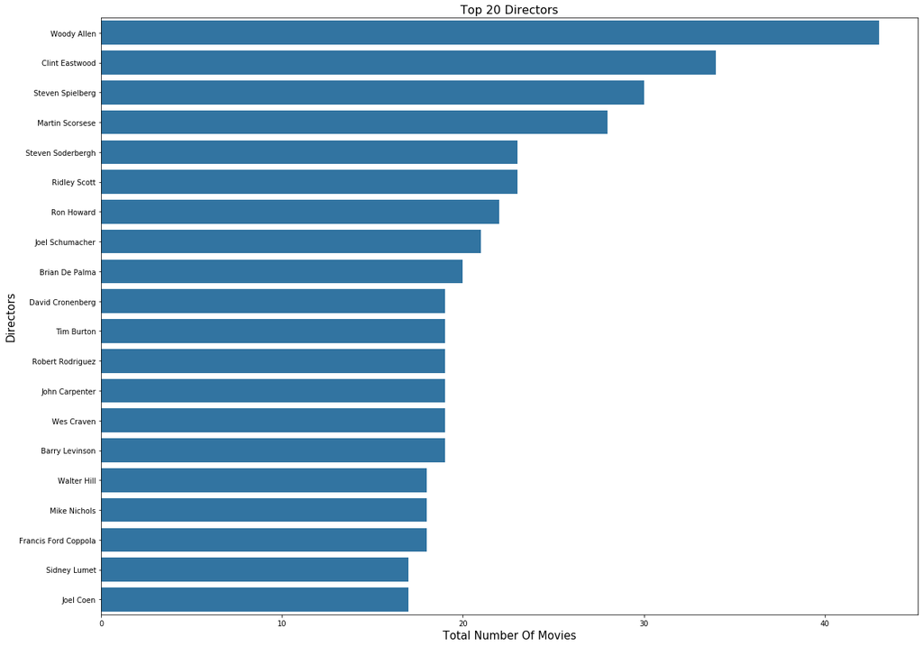

```python
#Cut the first 20 directors
new_directors_df = directors_df.iloc[:20]

#Set color for the bar graph
base_color = sns.color_palette()[0]
fig_dims = (20, 15)
fig, ax = plt.subplots(figsize = fig_dims)

#Plot the bargraph
sns.barplot(data = new_directors_df, x = 'movies_directed', y = 'director', color = base_color, ax = ax);

#Set the title and axes
plt.title("Top 20 Directors", fontsize=16);
plt.xlabel("Total Number Of Movies",fontsize=15);
plt.ylabel("Directors",fontsize= 15);
```

> The plot above shows the top 20 directors who have directed the most movies. The top 3 are: **woody Allen**, **Clint Eastwood** and **Steven Spielberg**

### Question 2 : Which actors/actress have acted the most movies? Top 20.

```python
#Store the series in a dataframe
cast_df = counter('cast').to_frame('cast')

# Get unique values
cast_df = cast_df['cast'].value_counts().to_frame('cast').reset_index()

#rename columns
cast_df = cast_df.rename(columns={'index':'cast','cast':'movies_acted'})
```

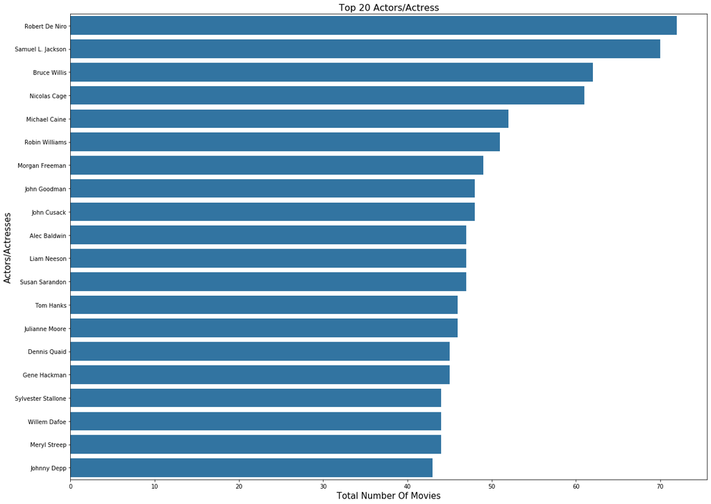

```python
#Cut the first 20
new_cast_df = cast_df.iloc[:20]

#Set color for the bar graph
base_color = sns.color_palette()[0]

#Set dimension size
fig_dims = (20, 15)
fig, ax = plt.subplots(figsize = fig_dims)

#Plot the bargraph
sns.barplot(data = new_cast_df, x = 'movies_acted', y = 'cast', color = base_color, ax = ax);

# Set title and axes
plt.title("Top 20 Actors/Actress", fontsize=16);
plt.xlabel("Total Number Of Movies",fontsize=15);
plt.ylabel("Actors/Actresses",fontsize= 15);
```

> The plot above shows the top 20 actors and actresses who have acted the most movies. The top actors/actresses are **Robert De Niro**, **Samuel L. Jackson** and **Bruce Wills**.

### Question 3 : Which genres have the highest release? Top 20.

```python
#Convert the panda series to dataframe
genre_df = counter('genres').to_frame('genres')

#Find unique values for each genre
genre_df = genre_df['genres'].value_counts().to_frame('genres').reset_index()

#rename the columns
genre_df = genre_df.rename(columns={'index':'genres','genres':'numof_genre_produced'})
```

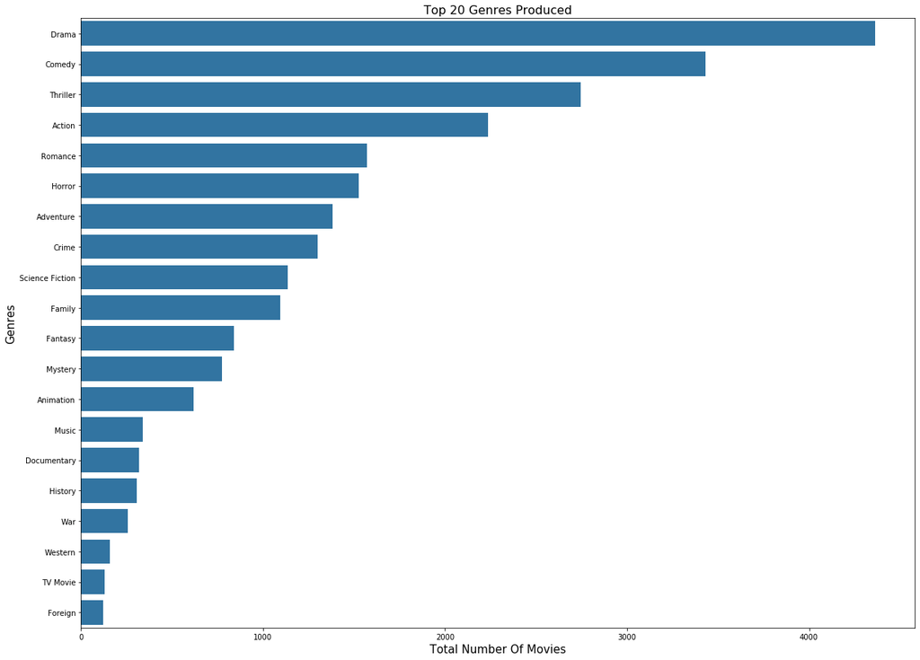

```python
#Set color for the bar graph
base_color = sns.color_palette()[0]

#Set dimension size
fig_dims = (20, 15)
fig, ax = plt.subplots(figsize = fig_dims)

# Plot the bargraph
sns.barplot(data = genre_df, x = 'numof_genre_produced', y = 'genres', color = base_color, ax = ax);

# Set the title and axes
plt.title("Top 20 Genres Produced", fontsize=16);
plt.xlabel("Total Number Of Movies",fontsize=15);
plt.ylabel("Genres",fontsize= 15);
```

### Question 4 : Which production companies have produced the most movies? Top 20.

```python
#Convert the panda series to dataframe
production_companies_df = counter('production_companies').to_frame('production_companies')

#Find unique values for each genre
production_companies_df = production_companies_df['production_companies'].value_counts().to_frame('production_companies').reset_index()

#rename the columns
production_companies_df = production_companies_df.rename(columns={'index':'production_companies','production_companies':'movies_produced'})
```

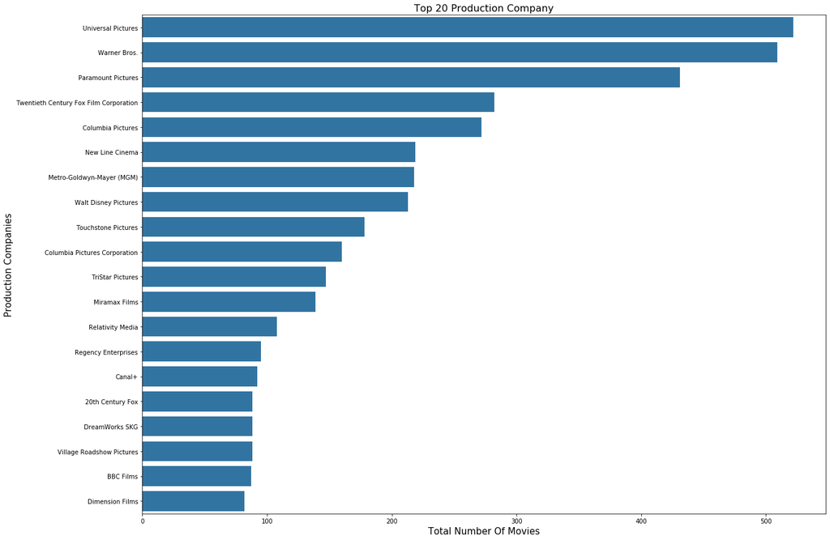

```python
#Cut the first 20 production companies
new_production_companies_df = production_companies_df.iloc[:20]

#Set color for the bar graph
base_color = sns.color_palette()[0]

#Set dimension size
fig_dims = (20, 15)
fig, ax = plt.subplots(figsize = fig_dims)

#Plot the bargraph
sns.barplot(data = new_production_companies_df, x = 'movies_produced', y = 'production_companies', color = base_color, ax = ax);

#Set the title and axes
plt.title("Top 20 Production Company", fontsize=16);
plt.xlabel("Total Number Of Movies",fontsize=15);
plt.ylabel("Production Companies",fontsize= 15);
```

> The plot above shows the top 20 production companies with the highest number of movies produced. THe top three are **Universal Pictures**, **Warner Bros** and **Paramount Pictures**.

### Question 5 : Which year has the highest movie release?

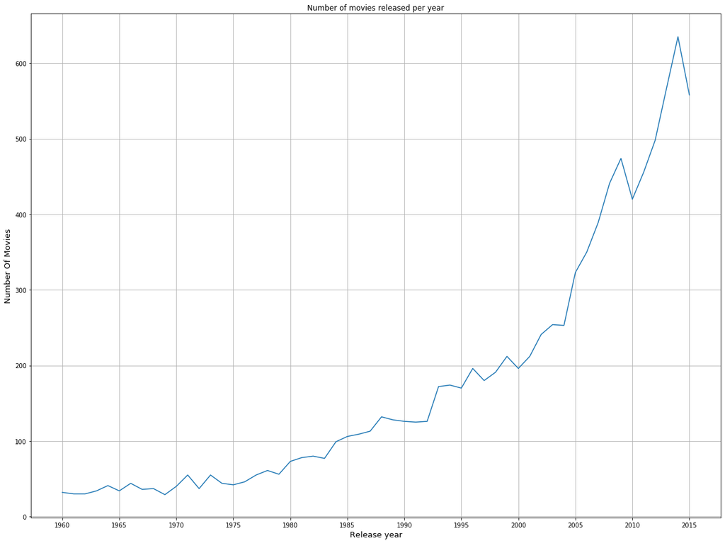

```python
#Set dimension size
fig_dims = (20, 15)
fig, ax = plt.subplots(figsize = fig_dims)

# Calculate the number of movies per year
releases = movie_df.groupby('release_year').count()['id']
releases.plot(xticks = np.arange(1960,2016,5), ax=ax);
plt.grid()

plt.title("Number of movies released per year");
plt.xlabel('Release year',fontsize = 13);
plt.ylabel('Number Of Movies',fontsize = 13);
```

> The above line plot shows year with the number of movies produced throughout the years with **1969** having the lowest number of movies produced and **2014** having the highest number of movies produced.

### Question 6 : Which movies have longest runtime?

```python
# Make a copy of the original dataframe
movie_copy = movie_df.copy()

# Copy the 'original_title' and 'runtime'
runtime_df = movie_copy[['original_title','runtime']]

#Sort in descending order
runtime_df.sort_values('runtime', ascending = False, inplace = True)
```

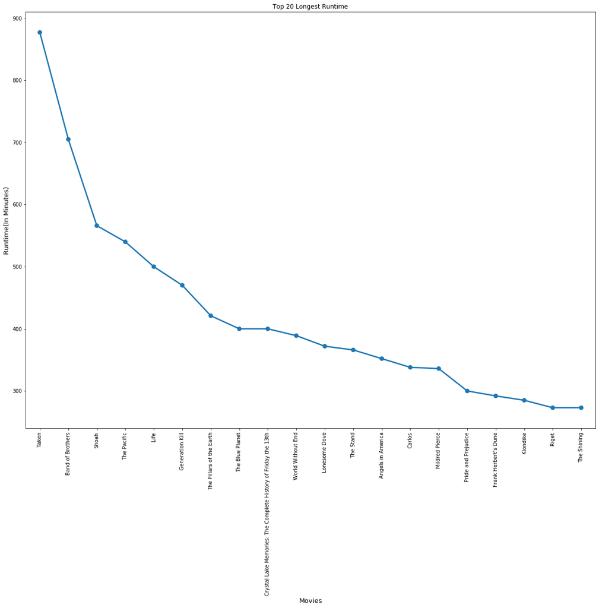

```python
#Take top 20 rows
top_runtime_df = runtime_df.head(20)

#Set dimension size
fig_dims = (20, 15)
fig, ax = plt.subplots(figsize = fig_dims)

# Set the x and y axes
x = list(top_runtime_df['original_title'])
y = list(top_runtime_df['runtime'])


# Plot the pointplot
sns.pointplot(data = top_runtime_df, x = x, y = y, ax=ax )
plt.xticks(rotation = 90)

# Set title and axes
plt.title("Top 20 Longest Runtime");
plt.xlabel('Movies',fontsize = 13);
plt.ylabel('Runtime(In Minutes)',fontsize = 13);
```

### Question 7 : Which movies have the highest and lowest ratings?

```python
#Create a function that finds the maximum and minimum values
def min_max(column):

    #find the lowest index in a panda series
    min_index = movie_df[column].idxmin()

    #find the highest index in a panda series
    max_index = movie_df[column].idxmax()

    # Find the highest and lowest entries
    highest_entry = pd.DataFrame(movie_df.loc[max_index,:])
    lowest_entry = pd.DataFrame(movie_df.loc[min_index,:])

    #Results
    print("The Movie with the highest " + column + " : ", movie_df['original_title'][max_index])
    print("The Movie with the lowest " + column + " : ", movie_df['original_title'][min_index])
    return pd.concat([highest_entry,lowest_entry],axis = 1)

# Find highest and lowest vote averages
min_max('vote_average')
```

```
The Movie with the highest vote_average :  Pink Floyd: Pulse
The Movie with the lowest vote_average :  Transmorphers
```

|  | 6911 | 7772 |
| --- | --- | --- |
| id | 24970 | 25055 |
| popularity | 0.21201 | 0.12112 |
| budget | NaN | NaN |
| revenue | NaN | NaN |
| original_title | Pink Floyd: Pulse | Transmorphers |
| cast | David Gilmour\|Nick Mason\|Richard Wright\|Sam Br... | Matthew Wolf\|Amy Weber\|Shaley Scott\|Eliza Swen... |
| director | David Mallet | Leigh Scott |
| runtime | 145 | 86 |
| genres | Music | Action\|Adventure\|Science Fiction |
| production_companies | SMV Enterprises\|Columbia Music Video\|EMI | Asylum, The |
| release_date | 2006-07-09 00:00:00 | 2007-06-26 00:00:00 |
| vote_count | 23 | 10 |
| vote_average | 8.7 | 1.5 |
| release_year | 2006 | 2007 |

```python
# Save 'original_title' and 'vote_average' in a new dataframe
rating_df = movie_copy[['original_title','vote_average']]

#Sort the dataframe in descending order
rating_df.sort_values('vote_average', ascending = False, inplace = True)
```

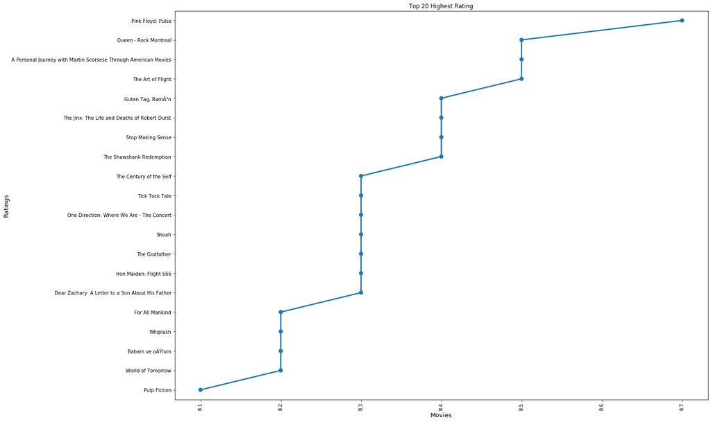

```python
# Take to 20 rows
top_rating_df = rating_df.head(20)

#Set dimension size
fig_dims = (20, 15)
fig, ax = plt.subplots(figsize = fig_dims)

# Set the x and y axes
x = list(top_rating_df['original_title'])
y = list(top_rating_df['vote_average'])


# Calculate the top 10 longest runtime
sns.pointplot(data = top_rating_df, x = y, y = x, ax=ax )
plt.xticks(rotation = 90)

#Set the title and axes
plt.title("Top 20 Highest Rating");
plt.xlabel('Movies',fontsize = 13);
plt.ylabel('Ratings',fontsize = 13);
```

### Question 8 : Which movies have the highest and lowest budget? Top 20.

```python
#Find highest and lowest budgets
min_max('budget')
```

```
The Movie with the highest budget :  The Warrior's Way
The Movie with the lowest budget :  Fear Clinic
```

|  | 2244 | 1151 |
| --- | --- | --- |
| id | 46528 | 287524 |
| popularity | 0.25054 | 0.177102 |
| budget | 4.25e+08 | 1 |
| revenue | 1.10876e+07 | NaN |
| original_title | The Warrior's Way | Fear Clinic |
| cast | Kate Bosworth\|Jang Dong-gun\|Geoffrey Rush\|Dann... | Thomas Dekker\|Robert Englund\|Cleopatra Coleman... |
| director | Sngmoo Lee | Robert Hall |
| runtime | 100 | 95 |
| genres | Adventure\|Fantasy\|Action\|Western\|Thriller | Horror |
| production_companies | Boram Entertainment Inc. | Dry County Films\|Anchor Bay Entertainment\|Movi... |
| release_date | 2010-12-02 00:00:00 | 2014-10-31 00:00:00 |
| vote_count | 74 | 15 |
| vote_average | 6.4 | 4.1 |
| release_year | 2010 | 2014 |

```python
# Save 'original_title' and 'budget' to a new dataframe
budget_df = movie_copy[['original_title','budget']]

# Sort data in descending order
budget_df.sort_values('budget', ascending = False, inplace = True)
```

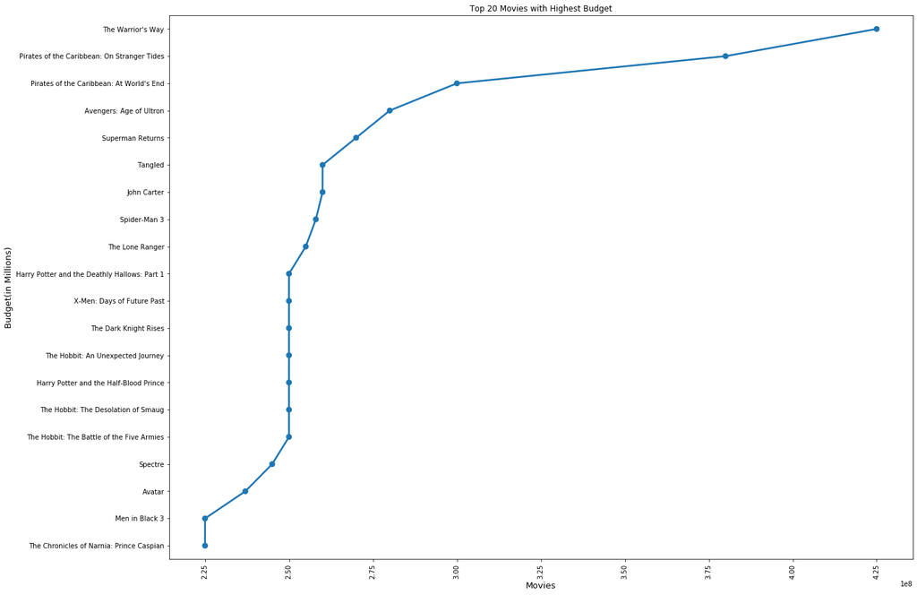

```python
# Take the top 20 rows
top_budget_df = budget_df.head(20)

#Set dimension size
fig_dims = (20, 15)
fig, ax = plt.subplots(figsize = fig_dims)

# Set the x and y axes
x = list(top_budget_df['original_title'])
y = list(top_budget_df['budget'])


# Plot the pointplots
sns.pointplot(data = top_budget_df, x = y, y = x, ax=ax )
plt.xticks(rotation = 90)


#Se the title and axes
plt.title("Top 20 Movies with Highest Budget");
plt.xlabel('Movies',fontsize = 13);
plt.ylabel('Budget(in Millions)',fontsize = 13);
```

> The point plot above shows top 20 movies with the highest budget. The top 3 are **The Worrior's Way**, **Pirates of the Carribean : On Stranger's Tide** and **Pirates of the Carribean : At World's End**

### Question 9 : Which movies have the highest and lowest revenue? Top 20.

```python
#Find highest and lowest revenue
min_max('revenue')
```

```
The Movie with the highest revenue :  Avatar
The Movie with the lowest revenue :  Shattered Glass
```

|  | 1386 | 5067 |
| --- | --- | --- |
| id | 19995 | 13537 |
| popularity | 9.43277 | 0.462609 |
| budget | 2.37e+08 | 6e+06 |
| revenue | 2.78151e+09 | 2 |
| original_title | Avatar | Shattered Glass |
| cast | Sam Worthington\|Zoe Saldana\|Sigourney Weaver\|S... | Hayden Christensen\|Peter Sarsgaard\|ChloÃ« Sevi... |
| director | James Cameron | Billy Ray |
| runtime | 162 | 94 |
| genres | Action\|Adventure\|Fantasy\|Science Fiction | Drama\|History |
| production_companies | Ingenious Film Partners\|Twentieth Century Fox ... | Lions Gate Films\|Cruise/Wagner Productions\|Bau... |
| release_date | 2009-12-10 00:00:00 | 2003-11-14 00:00:00 |
| vote_count | 8458 | 46 |
| vote_average | 7.1 | 6.4 |
| release_year | 2009 | 2003 |

```python
# Save 'original_title' and 'revenue'
revenue_df = movie_copy[['original_title','revenue']]

#Sort in descending order
revenue_df.sort_values('revenue', ascending = False, inplace = True)
```

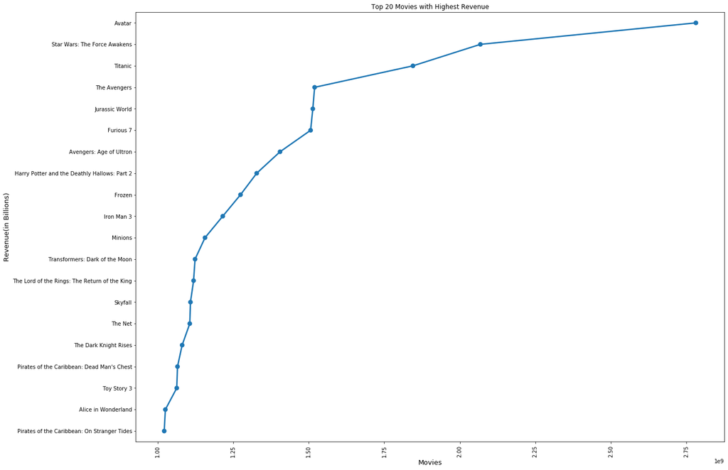

```python
#Take top 20 rows
top_revenue_df = revenue_df.head(20)

#Set dimension size
fig_dims = (20, 15)
fig, ax = plt.subplots(figsize = fig_dims)

#Set the x and y axes
x = list(top_revenue_df['original_title'])
y = list(top_revenue_df['revenue'])


# Plot the pointplot
sns.pointplot(data = top_revenue_df, x = y, y = x, ax=ax )
plt.xticks(rotation = 90)

#Set title and axes
plt.title("Top 20 Movies with Highest Revenue");
plt.xlabel('Movies',fontsize = 13);
plt.ylabel('Revenue(in Billions)',fontsize = 13);
```

> The pointplot above shows the top 20 movies with highest revenues. The top 3 are **Avatar**, **Star Wars : The Force Awakens** and **Titanic**.

### Question 10: Which movies have the highest profit and loss? Top 20.

```python
# Calculate profits
movie_df['profits'] = movie_df['revenue'] - movie_df['budget']

#Find highest and lowest profits
min_max('profits')
```

```
The Movie with the highest profits :  Avatar
The Movie with the lowest profits :  The Warrior's Way
```

|  | 1386 | 2244 |
| --- | --- | --- |
| id | 19995 | 46528 |
| popularity | 9.43277 | 0.25054 |
| budget | 2.37e+08 | 4.25e+08 |
| revenue | 2.78151e+09 | 1.10876e+07 |
| original_title | Avatar | The Warrior's Way |
| cast | Sam Worthington\|Zoe Saldana\|Sigourney Weaver\|S... | Kate Bosworth\|Jang Dong-gun\|Geoffrey Rush\|Dann... |
| director | James Cameron | Sngmoo Lee |
| runtime | 162 | 100 |
| genres | Action\|Adventure\|Fantasy\|Science Fiction | Adventure\|Fantasy\|Action\|Western\|Thriller |
| production_companies | Ingenious Film Partners\|Twentieth Century Fox ... | Boram Entertainment Inc. |
| release_date | 2009-12-10 00:00:00 | 2010-12-02 00:00:00 |
| vote_count | 8458 | 74 |
| vote_average | 7.1 | 6.4 |
| release_year | 2009 | 2010 |
| profits | 2.54451e+09 | -4.13912e+08 |

```python
#Copy the dataframe
movie_copy = movie_df.copy()

#Save 'original_title' and 'profits'
profits_df = movie_copy[['original_title','profits']]

#Sort in descending order
profits_df.sort_values('profits', ascending = False, inplace = True)
```

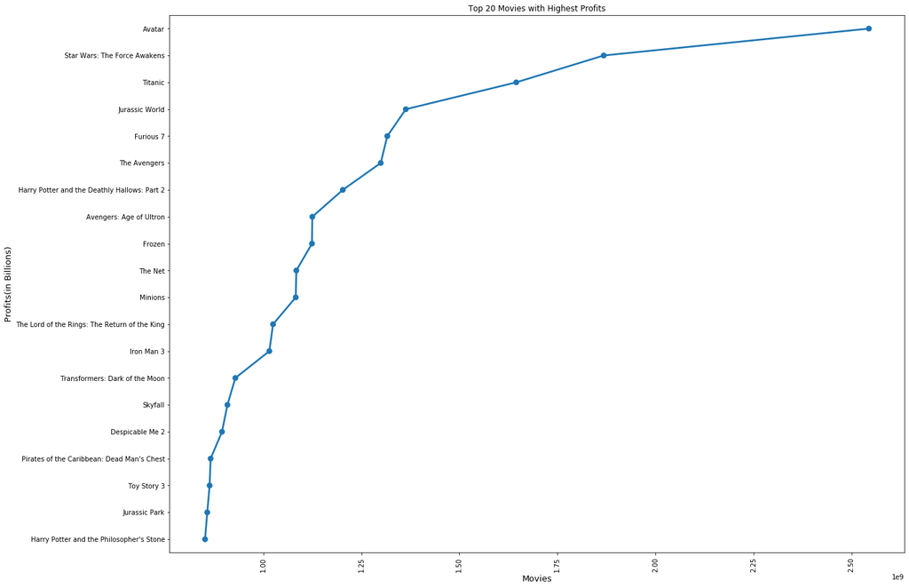

```python
#Take top 20 rows
top_profits_df = profits_df.head(20)

#Set dimension size
fig_dims = (20, 15)
fig, ax = plt.subplots(figsize = fig_dims)

#Set x and y axes
x = list(top_profits_df['original_title'])
y = list(top_profits_df['profits'])


# plot the pointplots
sns.pointplot(data = top_profits_df, x = y, y = x, ax=ax )
plt.xticks(rotation = 90)

#Set title and axes
plt.title("Top 20 Movies with Highest Profits");
plt.xlabel('Movies',fontsize = 13);
plt.ylabel('Profits(in Billions)',fontsize = 13);
```

> The pointplot above shows the top 20 movies with highest profits. The top 3 are **Avatar**, **Star Wars : The Force Awakens** and **Titanic**.

### Question 11 : Which properties are associated with high profits and ratings.

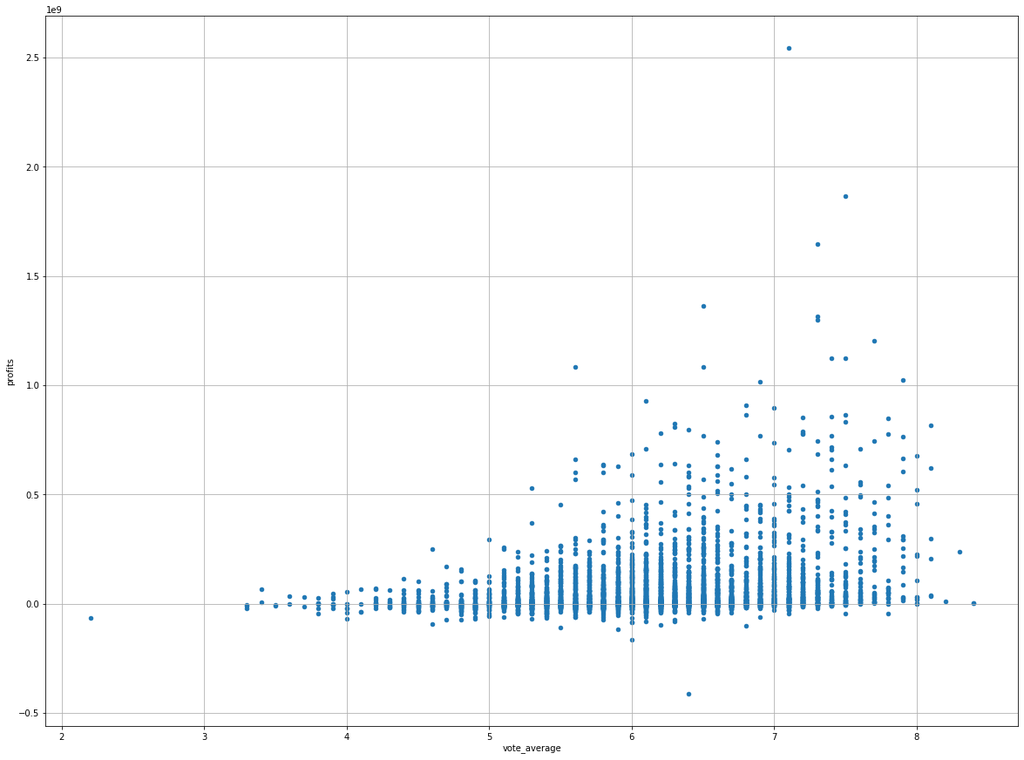

```python
#Find the relationship between vote_average and profit earned by movies
movie_df.plot.scatter(x='vote_average', y='profits', figsize=(20, 15));
plt.grid()
```

```python
#Create a dataframe of movies with vote_average more than or equal to 6
high_rated_profitable_df = movie_df.query('vote_average >= 6')
high_rated_profitable_df.head()
```

|  | id | popularity | budget | revenue | original_title | cast | director | runtime | genres | production_companies | release_date | vote_count | vote_average | release_year | profits |
| --- | --- | --- | --- | --- | --- | --- | --- | --- | --- | --- | --- | --- | --- | --- | --- |
| 0 | 135397 | 32.985763 | 150000000.0 | 1.513529e+09 | Jurassic World | Chris Pratt\|Bryce Dallas Howard\|Irrfan Khan\|Vi... | Colin Trevorrow | 124.0 | Action\|Adventure\|Science Fiction\|Thriller | Universal Studios\|Amblin Entertainment\|Legenda... | 2015-06-09 | 5562 | 6.5 | 2015 | 1.363529e+09 |
| 1 | 76341 | 28.419936 | 150000000.0 | 3.784364e+08 | Mad Max: Fury Road | Tom Hardy\|Charlize Theron\|Hugh Keays-Byrne\|Nic... | George Miller | 120.0 | Action\|Adventure\|Science Fiction\|Thriller | Village Roadshow Pictures\|Kennedy Miller Produ... | 2015-05-13 | 6185 | 7.1 | 2015 | 2.284364e+08 |
| 2 | 262500 | 13.112507 | 110000000.0 | 2.952382e+08 | Insurgent | Shailene Woodley\|Theo James\|Kate Winslet\|Ansel... | Robert Schwentke | 119.0 | Adventure\|Science Fiction\|Thriller | Summit Entertainment\|Mandeville Films\|Red Wago... | 2015-03-18 | 2480 | 6.3 | 2015 | 1.852382e+08 |
| 3 | 140607 | 11.173104 | 200000000.0 | 2.068178e+09 | Star Wars: The Force Awakens | Harrison Ford\|Mark Hamill\|Carrie Fisher\|Adam D... | J.J. Abrams | 136.0 | Action\|Adventure\|Science Fiction\|Fantasy | Lucasfilm\|Truenorth Productions\|Bad Robot | 2015-12-15 | 5292 | 7.5 | 2015 | 1.868178e+09 |
| 4 | 168259 | 9.335014 | 190000000.0 | 1.506249e+09 | Furious 7 | Vin Diesel\|Paul Walker\|Jason Statham\|Michelle ... | James Wan | 137.0 | Action\|Crime\|Thriller | Universal Pictures\|Original Film\|Media Rights ... | 2015-04-01 | 2947 | 7.3 | 2015 | 1.316249e+09 |

> Our main goal is to look for properties that are related to highly rated and profitable movies. Therefore let's check for those movies whose profit is more than or equal to 10 million dollars.

```python
# Find profits greater than 10 million
high_rated_profitable_df = high_rated_profitable_df.query('profits >= 10000000')
high_rated_profitable_df.head()
```

|  | id | popularity | budget | revenue | original_title | cast | director | runtime | genres | production_companies | release_date | vote_count | vote_average | release_year | profits |
| --- | --- | --- | --- | --- | --- | --- | --- | --- | --- | --- | --- | --- | --- | --- | --- |
| 0 | 135397 | 32.985763 | 150000000.0 | 1.513529e+09 | Jurassic World | Chris Pratt\|Bryce Dallas Howard\|Irrfan Khan\|Vi... | Colin Trevorrow | 124.0 | Action\|Adventure\|Science Fiction\|Thriller | Universal Studios\|Amblin Entertainment\|Legenda... | 2015-06-09 | 5562 | 6.5 | 2015 | 1.363529e+09 |
| 1 | 76341 | 28.419936 | 150000000.0 | 3.784364e+08 | Mad Max: Fury Road | Tom Hardy\|Charlize Theron\|Hugh Keays-Byrne\|Nic... | George Miller | 120.0 | Action\|Adventure\|Science Fiction\|Thriller | Village Roadshow Pictures\|Kennedy Miller Produ... | 2015-05-13 | 6185 | 7.1 | 2015 | 2.284364e+08 |
| 2 | 262500 | 13.112507 | 110000000.0 | 2.952382e+08 | Insurgent | Shailene Woodley\|Theo James\|Kate Winslet\|Ansel... | Robert Schwentke | 119.0 | Adventure\|Science Fiction\|Thriller | Summit Entertainment\|Mandeville Films\|Red Wago... | 2015-03-18 | 2480 | 6.3 | 2015 | 1.852382e+08 |
| 3 | 140607 | 11.173104 | 200000000.0 | 2.068178e+09 | Star Wars: The Force Awakens | Harrison Ford\|Mark Hamill\|Carrie Fisher\|Adam D... | J.J. Abrams | 136.0 | Action\|Adventure\|Science Fiction\|Fantasy | Lucasfilm\|Truenorth Productions\|Bad Robot | 2015-12-15 | 5292 | 7.5 | 2015 | 1.868178e+09 |
| 4 | 168259 | 9.335014 | 190000000.0 | 1.506249e+09 | Furious 7 | Vin Diesel\|Paul Walker\|Jason Statham\|Michelle ... | James Wan | 137.0 | Action\|Crime\|Thriller | Universal Pictures\|Original Film\|Media Rights ... | 2015-04-01 | 2947 | 7.3 | 2015 | 1.316249e+09 |

> We now have a dataframe containing movies that are highly rated and are profitable. We therefore need to check properties that are associated with this dataframe. The properties that we will be checking for are:

> Genres

> Production Companies

> Actors/Actresses

> Directors

```python
#Most frequent genres for highly rated and profitable movies

#Function to split the genres and count them
def highly_rated_profitable_counter(column):

    #join all the entries in the column to a single string
    concat_str = high_rated_profitable_df[column].str.cat(sep='|')

    # Change the string to series
    sep_str = pd.Series(concat_str.split(sep='|'))

    return sep_str
```

#### Genres Associated with Highly Rated and Profitable Movies

```python
rp_genre_df = highly_rated_profitable_counter('genres').to_frame('genres')
rp_genre_df = rp_genre_df['genres'].value_counts().to_frame('genres').reset_index()
rp_genre_df = rp_genre_df.rename(columns={'index':'genres','genres':'genres_produced'})
```

```python
#Cut the first 20
rp_genre_df2 = rp_genre_df.iloc[:20]
rp_genre_df2.info()
```

```
<class 'pandas.core.frame.DataFrame'>
RangeIndex: 18 entries, 0 to 17
Data columns (total 2 columns):
 #   Column           Non-Null Count  Dtype
---  ------           --------------  -----
 0   genres           18 non-null     object
 1   genres_produced  18 non-null     int64
dtypes: int64(1), object(1)
memory usage: 416.0+ bytes
```

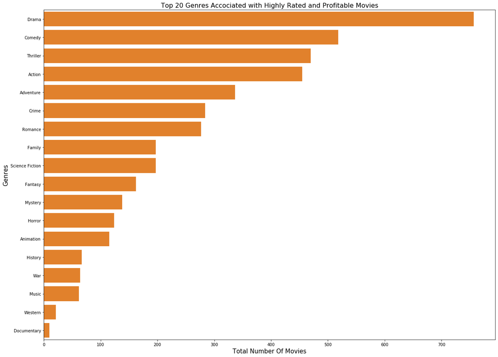

```python
#Set color for the bar graph
base_color = sns.color_palette()[1]
fig_dims = (20, 15)
fig, ax = plt.subplots(figsize = fig_dims)

sns.barplot(data = rp_genre_df2, x = 'genres_produced', y = 'genres', color = base_color, ax = ax);

plt.title("Top 20 Genres Accociated with Highly Rated and Profitable Movies", fontsize=16);
plt.xlabel("Total Number Of Movies",fontsize=15);
plt.ylabel("Genres",fontsize= 15);
```

#### Production Companies Associated with Highly Rated and Profitable Movies

```python
rp_production_companies_df = highly_rated_profitable_counter('production_companies').to_frame('production_companies')
rp_production_companies_df = rp_production_companies_df['production_companies'].value_counts().to_frame('production_companies').reset_index()
rp_production_companies_df = rp_production_companies_df.rename(columns={'index':'production_companies','production_companies':'movies_produced'})
```

```python
#Cut the first 20
rp_production_companies_df2 = rp_production_companies_df.iloc[:20]
```

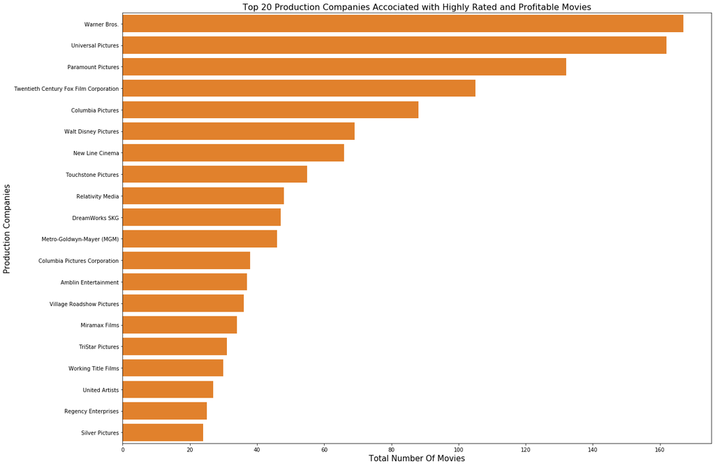

```python
#Set color for the bar graph
base_color = sns.color_palette()[1]
fig_dims = (20, 15)
fig, ax = plt.subplots(figsize = fig_dims)

sns.barplot(data = rp_production_companies_df2, x = 'movies_produced', y = 'production_companies', color = base_color, ax = ax);

plt.title("Top 20 Production Companies Accociated with Highly Rated and Profitable Movies", fontsize=16);
plt.xlabel("Total Number Of Movies",fontsize=15);
plt.ylabel("Production Companies",fontsize= 15);
```

#### Actors and Actess

```python
rp_cast_df = highly_rated_profitable_counter('cast').to_frame('cast')
rp_cast_df = rp_cast_df['cast'].value_counts().to_frame('cast').reset_index()
rp_cast_df = rp_cast_df.rename(columns={'index':'cast','cast':'movies_acted'})
```

```python
#Cut the first 20
rp_cast_df2 = rp_cast_df.iloc[:20]
```

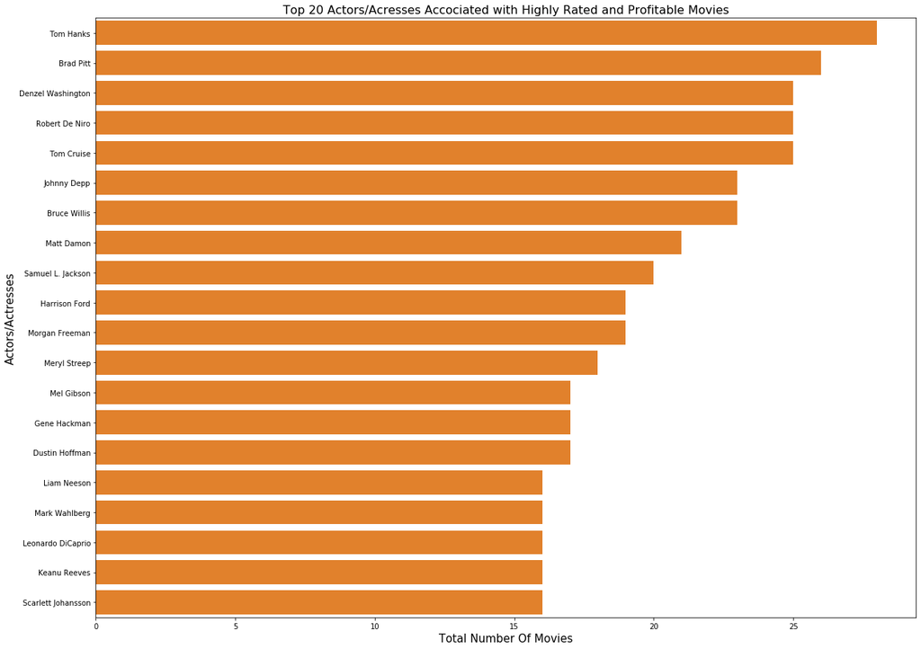

```python
#Set color for the bar graph
base_color = sns.color_palette()[1]
fig_dims = (20, 15)
fig, ax = plt.subplots(figsize = fig_dims)

sns.barplot(data = rp_cast_df2, x = 'movies_acted', y = 'cast', color = base_color, ax = ax);

plt.title("Top 20 Actors/Acresses Accociated with Highly Rated and Profitable Movies", fontsize=16);
plt.xlabel("Total Number Of Movies",fontsize=15);
plt.ylabel("Actors/Actresses",fontsize= 15);
```

```python
#DIRECTORS
```

```python
rp_directors_df = highly_rated_profitable_counter('director').to_frame('director')
rp_directors_df = rp_directors_df['director'].value_counts().to_frame('director').reset_index()
rp_directors_df = rp_directors_df.rename(columns={'index':'director','director':'movies_directed'})
```

```python
#Cut the first 20
rp_directors_df2 = rp_directors_df.iloc[:20]
```

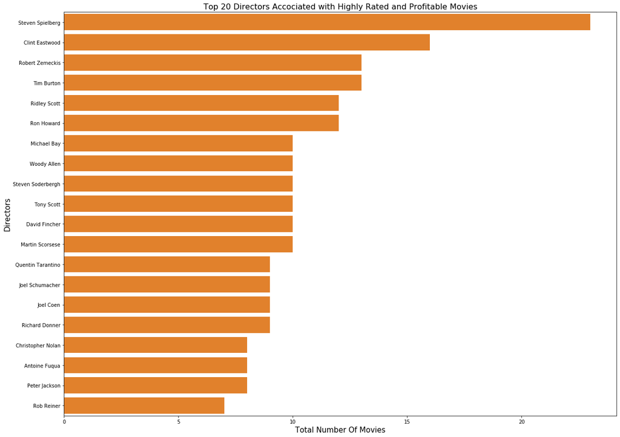

```python
#Set color for the bar graph
base_color = sns.color_palette()[1]
fig_dims = (20, 15)
fig, ax = plt.subplots(figsize = fig_dims)

sns.barplot(data = rp_directors_df2, x = 'movies_directed', y = 'director', color = base_color, ax = ax);

plt.title("Top 20 Directors Accociated with Highly Rated and Profitable Movies", fontsize=16);
plt.xlabel("Total Number Of Movies",fontsize=15);
plt.ylabel("Directors",fontsize= 15);
```

## Conclusions

A complete data analysis process was performed on The Movie Database (TMDb) dataset. Several Python libraries such as Numpy, Pandas, Matplotlib and Seaborn were used in the prosses. We came to the following conclusions.

1. Most Popular Genre: **Drama**
2. Production Company with Most Movies: **Universal Pictures**
3. Actors with Most Acted Movies: **Robert Di Niro**
4. Directors with Most Directed Movies: **Woody Allen**

1. Year with highest number of movies produced: **2014
2. Movie With Highest Profit: **Avatar**
3. Movie with Highest Loss: **The Worrior's Way**
4. Movie with Highest Budget: **The Worrior's Way**
5. Movie with Lowest Budget: **Fear Clinic**
6. Movie with Highest Revenue: **Avatar**
7. Movie with Lowest Revenue: **Shattered Glass**
8. Movie with longest runtime: **Taken**
9. Movie with highest ratings: **Pink Floyd : Pulse**

We also analysed properties that associated that are associated with Highly rated and Profitable movies and observed the following:

1. Genres: **Drama, Comedy and Thriller**
2. Production Companies: **Warner Bros, Universal Pictures and Paramount Pictures**
3. Actors: **Tom Hanks, Brad Pitt and Denzel Washington**
4. Directors: **Steven Spielberg, Clint Eastwood and Tim Burton**

### Limitations

1. Some data was lost during cleaning for example when we dropped rows that has any nulls. Some key information might have been lost with the data dropped.
2. The data is not upto date. Therefore there might be changes in the variables that we have been analysing.
3. The currency for 'budget' and 'revenue' was not clearly stated. We therefore are not sure if all of them were in dollars we are just assuming.
4. All the analysis we did was from the dataset provided. The analysis performed on this dataset might therefore be biased if wrong information was given in the dataset.

### Reference

Pandas Documentation

Numpy Documentation

Matplotlib Documentation

Seaborn Documentation

Kaggle

Github